# Towards a Risk Literacy Toolbox

Hansjörg Neth, SPDS, uni.kn

2018 01 05

# Basics

Note that this file served as an original test bed for the `riskyr` package and the corresponding Shiny app. (The latest code versions are now stored there, *not* here.)

## Customizations

### Text labels

Define some text labels:

### Graphical settings

Define graphical settings (e.g., colors and `ggplot2` themes):

# Basic Idea

Provide some useful visualizations of common risk information measures as interactive tools (in R and Shiny) for fostering transparent risk communication and teaching purposes.

## Mathematical Background

### Bayesian inference

```r
H.lbl <- "H" # Hypothesis
E.lbl <- "D" # Evidence (E) or Decision/Data (D)
```

*Bayes’ rule* describes the probability $p$ of a hypothesis $H$ given some evidence $D$ as:

$$p(H|D) = \frac{p(D|H) \times\ p(H)}
{p(D)}$$

By further decomposing the denominator $p(D)$ into two mutually exclusive parts $p(D|H) \times\ p(H) + p(D|\neg H) \times\ p(\neg H)$ we get:

$$p(H|D) = \frac{p(D|H) \times\ p(H)}
{p(D|H) \times\ p(H) +
p(D|\neg H) \times\ p(\neg H)}$$

### Probabilities vs. natural frequencies

Information (e.g., clinical variables) is often expressed as *probabilities* (e.g., `prev`) or even as *conditional probabilities* (`sens`/`spec`, `ppv`/`npv`).

Many quantities can be expressed either as *probabilities* or as *natural frequencies*. Although both representations are mathematically equivalent, a basic claim (e.g., by Gigerenzer et al.) is that people struggle when information is expressed in terms of probabilities, but not when the same information is expressed in terms of natural frequencies.

The notion of “Bayesian inference” looks and sounds complicated, but — at its core — we typically aim to understand the interplay between a small set of variables for a specific scenario.

### Scenario

Any example problem starts with the definition of a concrete *scenario*:

1. A specific *population* of size `N`;
2. A *condition* that is being considered (with 2 states `TRUE` vs. `FALSE`);
3. A *decision* (clinical judgment) that classifies the condition (into positive or negative, or a *judgment* of `TRUE` vs. `FALSE`);
4. Some *parameters* (typically *probabilities*) that are *provided* (see below);
5. Some *parameters* (typically *probabilities*) that are *asked* (see below).

### Environment parameters

Any specific scenario contains several numeric parameters that are either inputs or outputs.

1. *Prevalence*: `prev`
2. *Sensitivity*: `sens` = $p$(decision positive | condition true)
3. *Specificity*: `spec` = $p$(decision negative | condition false)

or

4. *False alarm rate*:  
   `fart`

#### Outputs

5. *Positive predictive value* `ppv`
6. *Negative predictive value* `npv`

### Number of cases

Note that we immediately translate *probabilities* into *natural frequencies*:

#### Truth conditions

1. Actual number of *true cases*:

`n.true` = `N` $\times$ `prev`

#### Decisions

1. Number of *positive decisions*:

`n.pos` = …

2. Number of *negative decisions*:

`n.neg` = …

#### Combinations (SDT)

1. Number of *hits* (aka. *true positives*):

`n.hi` = `n.true` $\times$ `sens`  
= `N` $\times$ `prev` $\times$ `sens`  
= `n.true` - `n.mi`

2. Number of *misses* (aka. *false negatives* or *omissions*) `n.mi`:

`n.mi` = `n.true` $\times$ (1 – `sens`)  
= (`N` $\times$ `prev`) $\times$ (1 – `sens`)  
= `n.true` – `n.hi`

3. Number of *false alarms* (aka. *false positives*):

`n.fa` = `n.false` $\times$ `fart`  
= `N` $\times$ (1 – `prev`) $\times$ `fart`  
= `N` $\times$ (1 – `prev`) $\times$ (1 – `spec`)  
= `n.false` – `n.cr`

4. Number of *correct rejections* (aka. *true negatives*):

`n.cr` = `n.false` $\times$ `spec`  
= `N` $\times$ (1 – `prev`) $\times$ `spec`  
= `n.false` – `n.fa`

### Predictive values

#### Positive predictive value ($PPV$)

**Definition:** In statistics and diagnostic tests, the *positive predictive value* ($PPV$) is the proportion of positive decisions that are true positives (hits).

In terms of natural frequencies, the $PPV$ is defined (quite simply) as:

$$\begin{aligned}
PPV &= \frac{\textrm{true positives}}{\textrm{positive decisions}}\\
&= \frac{\textrm{true positives}}{\textrm{true positives} + \textrm{false positives}}\\
&= \frac{\textrm{hits}}{\textrm{hits} + \textrm{false alarms}}
\end{aligned}$$

However, given that

- `n.hi` = `N` $\times$ `prev` $\times$ `sens`
- `n.fa` = `N` $\times$ (1 – `prev`) $\times$ (1 – `spec`)

we can express this (considerably more obscurely) as a fraction of probabilities:

$$\begin{aligned}
PPV &= \frac{(N \times\ prev) \times\ sens}
{(N \times\ prev) \times\ sens +
[N \times\ (1 - prev)] \times\ (1 - spec)}\\
&= \frac{prev \times\ sens}
{prev \times\ sens + (1 - prev) \times\ (1 - spec)}
\end{aligned}$$

3. $PPV$ is the *reversed conditional probability* of `sens`:
- $PPV$ = $p$(condition true | decision positive)
- `sens` = $p$(decision positive | condition true)
4. The *complement* of $PPV$ is the *false discovery rate* ($FDR$):

$$FDR = 1 - PPV$$

#### Negative predictive value ($NPV$)

**Definition:** In statistics and diagnostic tests, the *negative predictive value* ($NPV$) is the proportion of negative decisions that are true negatives (correct rejections).

1. In terms of natural frequencies, the $NPV$ is defined (quite simply) as:

$$\begin{aligned}
NPV &= \frac{true\ negatives}{negative\ decisions}\\
&= \frac{true\ negatives}{true\ negatives + false\ negatives}\\
&= \frac{correct\ rejections}{correct\ rejections\ + misses}
\end{aligned}$$

2. However, given that
- `n.cr` = `N` $\times$ (1 – `prev`) $\times$ `spec`
- `n.mi` = `N` $\times$ `prev` $\times$ (1 – `sens`)

we can express this (considerably more obscurely) as a fraction of probabilities:

$$\begin{aligned}
NPV &= \frac{N \times\ (1 - prev) \times\ spec}
{(N \times\ (1 - prev) \times\ spec) +
[N \times\ prev \times\ (1 - sens)]} \\
&= \frac{(1 - prev) \times\ spec}
{(1 - prev) \times\ spec + prev \times\ (1 - sens)}
\end{aligned}$$

3. $NPV$ is the *reversed conditional probability* of `spec`:
- $NPV$ = $p$(condition false | decision negative)
- `spec` = $p$(decision negative | condition false)
4. The *complement* of the $NPV$ is the *false omission rate* ($FOR$):

$$FOR = 1 - NPV$$

## Functionality

Our approach: From theories to tools (rather than the reverse, Gigerenzer, 1991a).

### Levels and perspectives

3 different levels with alternative perspectives:

1. Viewing population as collection of individuals or cases: table vs. icon array
2. Aggregation and categorization (SDT): confusion table, mosaic plot, tree of natural frequencies
3. Resulting posteriors: PV curves and planes

### Interactions: Sorting, sliding, and sampling:

1. *Sorting* is the opposite of *shuffling* (randomization):
2. *Sliders* and observing corresponding interactive and dynamic shifts of outputs as a function of own actions encourages viewing inputs as continuous variables (Gigerenzer et al., 1988) and thus may help to make cognitive illusions disappear (Gigerenzer, 1991b).
3. *Sampling* encourages differentiation of *population* vs. *sample* and a perspective *by description* and one *by experience*. Allows developing and testing intuitions about sample size (Sedlmeier & Gigerenzer, 1997).

## Initial Set of Tools

Based on a set of common parameters: population size `N`, prevalence `prev`, sensitivity `sens`, specificity `spec` (or false alarm rate `fa = 1 - spec`).

Allow setting and playing with basic parameters or reading in examples from the literature.

## Future extensions

1. Allow for randomization and sampling
2. Extend to decisions on non-dichotomous distributions (SDT).
3. Extend to the topics of scientific reasoning: *Cell A bias* and *biased evidence detection*.
4. Include info on screening biases (lead time vs. over-diagnosis bias).

# Basics

## Main Parameters

The following variables should be used (and updated) by all parts:

```r
## Inputs used in all representations:
# (a) as parameters:
N <- 100 # N in population
prev <- .15 # prevalence in population = p(true positive)
sens <- .85 # sensitivity = p(positive decision | true positive)
spec <- .75 # specificity = p(negative decision | true negative)

# (b) as environment list:
e1 <- list("name" = "Demo",  # name (e.g., HIV, mammography, ...)
           "N" = 100,        # N in population
           "prev" = .15,     # prevalence in population = p(true positive)
           "sens" = .85,     # sensitivity = p(positive decision | true positive)
           "spec" = .75,     # specificity = p(negative decision | true negative)
           "source" = "Source info" # information source (e.g., citation)
           )
```

Alternatively, we could define or read in a set of existing examples:

```r
## 1. HIV (a) [Source: Gigerenzer (2013), p. 53]:
name <- "HIVa"
N <- 100000     # women
prev <- 1/10000 # p(HIV)
sens <- 1.0     # p(pos | HIV )
spec <- (1 - 5/100000) # 1 - p(fa) = 1 - (pos | no HIV)
source <- "Gigerenzer (2013), p. 53"

## 2. HIV (b) [Source: Gigerenzer (2013), p. 53]:
name <- "HIVb"
N <- 250000     # women
prev <- 1/10000 # p(HIV)
sens <- 1.0     # p(pos | HIV )
spec <- (1 - 1/250000) # 1 - p(fa) = 1 - (pos | no HIV)
source <- "Gigerenzer (2013), p. 53"

## 3. Breast cancer  [Source: Gigerenzer (2013), p. 213--221]:
name <- "Breast cancer"
N <- 1000         # women (50yrs, no symptoms, routine mammography screening)
prev <- 10/1000   # p(breast cancer)
sens <- .90       # p(pos | breast cancer )
spec <- (1 - .09) # 1 - p(fa) = 1 - (pos | no breast cancer)
source <- "Gigerenzer (2013), p. 213--221"

## 4. Down syndrome  [Source: Gigerenzer (2013), p. 222--226]:
name <- "Down syndrome"
N <- 1000         # women (40yrs, pregnancy)
prev <- 10/1000   # p(Down syndrome)
sens <- .90       # p(pos | Down syndrome )
spec <- (1 - .05) # 1 - p(fa) = 1 - (pos | no Down syndrome)
source <- "Gigerenzer (2013), p. 222--226"

## ToDo: Define examples (values and labels) as a data frame (which can be read in or exported).
```

## Data Structures

1. Define some vectors of length `N` based on the (current) main variables:

```r
## (0) Get current parameters:
cur.env <- e1

name <- cur.env$name
N <- cur.env$N
prev <- cur.env$prev
sens <- cur.env$sens
spec <- cur.env$spec
source <- cur.env$source

## (1) Determine the truth:
n.true <- round((prev * N), 0)
n.false <- (N - n.true)

truth <- c(rep(TRUE, n.true), rep(FALSE, n.false))
# truth
sum(truth)
```

```
#> [1] 15
```

```r
## (2) Determine decisions:
n.hi <- round((sens * n.true), 0)  # hits
# n.hi
n.cr <- round((spec * n.false), 0) # correct rejections
# n.cr
n.mi <- (n.true - n.hi)            # misses
# n.mi
n.fa <- (n.false - n.cr)           # false alarms
# n.fa

decision <- c(rep(TRUE, n.hi), rep(FALSE, n.mi), rep(TRUE, n.fa), rep(FALSE, n.cr))
# decision
# sum(decision)

## (3) Combine truth and decisions:
both.true <-  truth & decision
both.false <-  !truth & !decision
correct.dec <- both.true | both.false
length(correct.dec)
```

```
#> [1] 100
```

```r
sum(correct.dec)/N
```

```
#> [1] 0.77
```

```r
## (4) Checks:
N == (n.hi + n.cr + n.mi + n.fa)
```

```
#> [1] TRUE
```

```r
length(truth) == length(decision)
```

```
#> [1] TRUE
```

```r
sum(truth) == n.hi + n.mi
```

```
#> [1] TRUE
```

```r
sum(decision) == n.hi + n.fa
```

```
#> [1] TRUE
```

```r
sum(both.true) == n.hi
```

```
#> [1] TRUE
```

```r
sum(both.false) == n.cr
```

```
#> [1] TRUE
```

```r
sum(correct.dec) == n.hi + n.cr
```

```
#> [1] TRUE
```

2. Populate the (total) population:

**Goal:** Define a common (global) data structure that is used and updated by all representations.

```r
## (1) Initialize the population of individuals:

## (a) Population as a vector of lists (each of which is an individual):
i <- list(tru = NA, # true state of the individual (Boolean)
          dec = NA, # decision on the individual (Boolean)
          sdt = ""  # category in SDT terms ("hi", "mi", "fa", "cr")
          )
population <- rep(i, N)

## Populate the population with the values from above:
population$tru <- truth
population$dec <- decision

population$sdt[population$tru & population$dec]   <- "hi"
population$sdt[population$tru & !population$dec]  <- "mi"
population$sdt[!population$tru & population$dec]  <- "fa"
population$sdt[!population$tru & !population$dec] <- "cr"

## (b) Population as a data frame:
population <- data.frame(tru = truth,
                         dec = decision,
                         sdt = NA)
names(population) <- c("truth", "decision", "sdt")

population$sdt[population$tru & population$dec]   <- "hi"
population$sdt[population$tru & !population$dec]  <- "mi"
population$sdt[!population$tru & population$dec]  <- "fa"
population$sdt[!population$tru & !population$dec] <- "cr"

# head(population)
# dim(population)

## (2) Make sdt an ordered factor:
population$sdt <- factor(population$sdt,
                         levels = c("hi", "mi", "fa", "cr"),
                         # labels = c("hit", "miss", "false alarm", "correct rejection"), # explicit labels
                         labels = c("hi", "mi", "fa", "cr"), # implicit labels
                         ordered = TRUE)
# is.factor(population$sdt)
# levels(population$sdt)

## Checks:
# population$sdt
table(population$sdt)
```

```
#>
#> hi mi fa cr
#> 13  2 21 64
```

```r
(sum(population$sdt == "hi") + sum(population$sdt == "cr"))/N # => accuracy
```

```
#> [1] 0.77
```

Note that defining `population` as a *data frame* allows immediate access to its variables (columns), cases (rows), and cells. Additionally, a rectangular population can be easily displayed, ex- or imported, and sampled.

# Tools

**Goal:** Provide a range of different perspectives on the same statistical relationships.

## 1. 2x2 confusion table

```r
## Compute natural frequencies:

## (1a) Generate from basic parameters (see above):
## 1st row:
# n.true <- round((prev * N), 0)
# n.false <- (N - n.true)
## 2nd row:
# n.hi <- round((sens * n.true), 0)  # hits
# n.cr <- round((spec * n.false), 0) # correct rejections
# n.mi <- (n.true - n.hi)            # misses
# n.fa <- (n.false - n.cr)           # false alarms

## (1b) get from current population:
n.true <- sum(population$tru == TRUE)
n.false <- sum(population$tru == FALSE)

dec.pos <- sum(population$dec == TRUE)
dec.neg <- sum(population$dec == FALSE)

n.hi <- sum(population$sdt == "hi")
n.mi <- sum(population$sdt == "mi")
n.fa <- sum(population$sdt == "fa")
n.cr <- sum(population$sdt == "cr")

# Checks:
N == n.true + n.false
```

```
#> [1] TRUE
```

```r
N == dec.pos + dec.neg
```

```
#> [1] TRUE
```

```r
n.true  == n.hi + n.mi
```

```
#> [1] TRUE
```

```r
n.false == n.fa + n.cr
```

```
#> [1] TRUE
```

```r
dec.pos == n.hi + n.fa
```

```
#> [1] TRUE
```

```r
dec.neg == n.mi + n.cr
```

```
#> [1] TRUE
```

```r
# (2) Define some derived metrics:
acc <- (n.hi + n.cr)/N
w.sens <- .50
bacc <- (w.sens * n.hi/(n.hi + n.mi)) + ((1 - w.sens) * n.cr/(n.cr + n.fa))

ppv <- n.hi / dec.pos # ppv = p(true positive | positive decision)
npv <- n.cr / dec.neg # npv = p(true negative | negative decision)
```

### Showing 2 x 2 confusion table

[output not shown]

**Derived metrics:**

### ToDo

- Make table colored and interactive (using cell values as inputs)
- Express `prev` as vertical threshold (to be moved from left-to-right to range from 0 to 1)
- Express `sensitivity` as horizontal threshold (…)

## 2. Tree of natural frequencies

```r
## Load required packages:
library("diagram")
# library("shape")

{
  #demo("flowchart")

  ## Example 1:
  #names <- c("A", "B", "C", "D")
  #M <- matrix(nrow = 4, ncol = 4, byrow = TRUE, data = 0)
  #plotmat(M, pos = c(1, 2, 1), name = names, lwd = 1,
  #        box.lwd = 2, cex.txt = 0.8, box.size = 0.1,
  #        box.type = "square", box.prop = 0.5)

  ## Example 2:
  #M[2, 1] <- M[3, 1] <- M[4, 2] <- M[4, 3] <- "flow"
  #plotmat(M, pos = c(1, 2, 1), curve = 0, name = names, lwd = 1,
  #        box.lwd = 2, cex.txt = 0.8, box.type = "circle", box.prop = 1.0)
}
```

```r
## New version of function
## (using default objects num, freq, txt, pal):

{
# plot_nftree <- function(prev = num$prev, sens = num$sens, spec = num$spec, fart = num$fart, # key parameters
#                         N = freq$N, n.true = freq$cond.true, n.false = freq$cond.false,     # freq info
#                         n.hi = freq$hi, n.mi = freq$mi, n.fa = freq$fa, n.cr = freq$cr,
#                         show.stuff = TRUE,           # user options [adjustable by inputs]
#                         title.lbl = txt$scen.lbl,    # custom labels
#                         popu.lbl = txt$popu.lbl,
#                         cond.lbl = txt$cond.lbl,     # condition
#                         cond.true.lbl = txt$cond.true.lbl,
#                         cond.false.lbl = txt$cond.false.lbl,
#                         dec.lbl = txt$dec.lbl,       # decision
#                         dec.true.lbl = txt$dec.true.lbl,
#                         dec.false.lbl = txt$dec.false.lbl,
#                         sdt.hi.lbl = txt$sdt.hi.lbl, # SDT combinations
#                         sdt.mi.lbl = txt$sdt.mi.lbl,
#                         sdt.fa.lbl = txt$sdt.fa.lbl,
#                         sdt.cr.lbl = txt$sdt.cr.lbl,
#                         # custom colors:
#                         col.N = col.sand.light, col.true = col.N, col.false = col.N,
#                         col.hi = pal["hi"], col.mi = pal["mi"], col.fa = pal["fa"], col.cr = pal["cr"],
#                         # shadow options:
#                         col.shadow = col.sand.dark, siz.shadow = 0 # [allow using shadows]
#                         ){
#
#     ## Graphic parameters (not adjusted by user):
#     # col.txt = grey(.01, alpha = .99)   # text
#     # col.border <- grey(.01, alpha = .99) # borders, shadows, ...
#     cex.txt <- 0.8 # adjust text size (on edges only?)
#     cex.lwd <- 2.0 # adjust line width
#
#     ## Labels:                                          # NOT used yet:
#     names <- c(paste0("Population", ":\n", "N = ", N),  # popu.lbl
#                paste0(cond.true.lbl, ":\n",  n.true),
#                paste0(cond.false.lbl, ":\n", n.false),
#                paste0(sdt.hi.lbl, ":\n", n.hi),
#                paste0(sdt.mi.lbl, ":\n", n.mi),
#                paste0(sdt.fa.lbl, ":\n", n.fa),
#                paste0(sdt.cr.lbl, ":\n", n.cr)
#     )
#
#     ## Make matrix M:
#     M <- matrix(nrow = 7, ncol = 8, byrow = TRUE, data = 0)
#
#     prev.lbl <- paste0("prev = ", as_pc(prev), "%")
#
#     M[2, 1] <- "prevalence"     # ERROR: WHY does prev.lbl not work???
#     M[3, 1] <- "(N - n.true)"
#     M[4, 2] <- "sensitivity"
#     M[5, 2] <- "(n.true - n.hi)"
#     M[6, 3] <- "(n.false - n.cr)"
#     M[7, 3] <- "specificity"
#
#     ## Plot matrix M:
#     pp <- plotmat(M,
#                   pos = c(1, 2, 4),
#                   curve = 0.0, # no curve (> 0 curve left, < 0 curve right)
#                   name = names,
#                   box.lwd = cex.lwd,
#                   box.size = .10,
#                   box.prop = 2/3,
#                   box.type = "square", # "circle",
#                   box.col = c(col.N, col.true, col.false, col.hi, col.mi, col.fa, col.cr), # WAS: "lightyellow"
#                   shadow.col = col.shadow,
#                   shadow.size = siz.shadow, # .005
#                   lwd = cex.lwd,
#                   cex.txt = cex.txt #,
#                   # main = paste0(title.lbl, ":\n", "Tree of natural frequencies (N = ", N, ")")
#                   )
#
#     ## Title:
#     p.title.lbl = paste0(title.lbl, ":\n", "Tree of natural frequencies") # , "(N = ", N, ")")
#     title(p.title.lbl, adj = 0.5, line = -1.5, font.main = 1) # (left, raised, normal font)
#
#     # return(pp)
#
# }

# ## Check:
# nftree <- plot_nftree()

}
```

```r
# typeof(nftree)
# str(nftree)
```

Second version (for `riskyr` package):

```r
## Load required packages:
library("diagram")
# library("shape")

{
  #demo("flowchart")

  ## Example 1:
  #names <- c("A", "B", "C", "D")
  #M <- matrix(nrow = 4, ncol = 4, byrow = TRUE, data = 0)
  #plotmat(M, pos = c(1, 2, 1), name = names, lwd = 1,
  #        box.lwd = 2, cex.txt = 0.8, box.size = 0.1,
  #        box.type = "square", box.prop = 0.5)

  ## Example 2:
  #M[2, 1] <- M[3, 1] <- M[4, 2] <- M[4, 3] <- "flow"
  #plotmat(M, pos = c(1, 2, 1), curve = 0, name = names, lwd = 1,
  #        box.lwd = 2, cex.txt = 0.8, box.type = "circle", box.prop = 1.0)
}
```

[figure not shown]

```r
## Function to plot tree of natural frequencies
## (using current environment variables (NOT population) as argument:
make.nftree <- function(env = cur.env) {

  ## Get current parameters:
  name <- cur.env$name
  N <- cur.env$N
  prev <- cur.env$prev
  sens <- cur.env$sens
  spec <- cur.env$spec
  source <- cur.env$source

  ## Tree with natural frequencies:
  ## Define names:
  names <- c(paste0("N = ", N), # Note: Using global variables (NOT population as argument)
             paste0(cond.true.lbl, ":\n",  n.true),
             paste0(cond.false.lbl, ":\n", n.false),
             paste0(sdt.hi.lbl, "s:\n",  n.hi),
             paste0(sdt.mi.lbl, "es:\n", n.mi),
             paste0(sdt.fa.lbl, "s:\n",  n.fa),
             paste0(sdt.cr.lbl, "s:\n",  n.cr)
  )

  ## Make matrix M:
  M <- matrix(nrow = 7, ncol = 8, byrow = TRUE, data = 0)

  M[2, 1] <- "prevalence" # paste0("prevalence = ", as.character(prev))
  M[3, 1] <- "(N - true)"
  M[4, 2] <- "sensitivity"
  M[5, 2] <- "(true - hi)"
  M[6, 3] <- "(false - cr)"
  M[7, 3] <- "specificity"

  ## Plot matrix M:
  pp <- plotmat(M,
                pos = c(1, 2, 4),
                curve = 0.0,
                name = names,
                box.lwd = 1.5, # radx = 0.1, # rady = 0.05,
                box.size = .10,
                box.prop = 0.5,
                box.type = "square", # "circle",
                box.col = c(rep(col.sand.light, 3), sdt.colors[c("hi", "mi", "fa", "cr")]), # "lightyellow"
                shadow.col = "steelblue4", # "grey25"
                shadow.size = 0.0, # .005
                lwd = 1.2,
                cex.txt = .90,
                main = paste0(name, ":\nTree of natural frequencies\n", "(", source, ")")
  )

  return(pp)

}

## Check:
nftree <- make.nftree(cur.env)
```

```r
# typeof(nftree)
# str(nftree)
```

## 3. Icon arrays

Visualize the population, using a common scheme of colors and symbols in all representations.

[To be discussed with Nathaniel.]

## 4. Graphical illustrations of PPV/NPV

### 2D graph

The following graphs illustrate how – for given test characteristics of `sens` and `spec` – the metrics `PPV` and `NPV` crucially depend on the *prevalence* (`prev`) in the population:

#### Using `ggplot2`

```r
# sens <- .90 # sensitivity
# spec <- .91 # specificity

# Specify a vector of prevalences:
{
  step.0 <- .10
  prev.0 <- seq(0, 10 * step.0, by = step.0)
  step.1 <- .001
  prev.1 <- seq(step.1, 10 * step.1, by = step.1)
  step.2 <- .01
  prev.2 <- seq(step.2, 10 * step.2, by = step.2)
  step.3 <- .05
  prev.3 <- seq(step.3, 20 * step.3, by = step.3)
  step.4 <- .01
  prev.4 <- seq(.90, .90 + 10 * step.4, by = step.4)
  step.5 <- .001
  prev.5 <- seq(.990, .990 + 10 * step.5, by = step.5)

  prev.range <- sort(unique(c(prev.0, prev.1, prev.2, prev.3, prev.4, prev.5)))
  # prev.range <- prev.range[prev.range > 0] # remove prev = 0
  # prev.range <- prev.range[prev.range < 1] # remove prev = 1
  ## Hack to prevent -Inf on log scale:
  epsilon <- 1/1000000 # some very small constant
  prev.range[prev.range == 0] <- 0 + epsilon # slightly more than 0
  prev.range[prev.range == 1] <- 1 - epsilon # slightly less than 1
  # prev.range
  # log10(get.PPV(prev.range, .5, .5)) # => -Inf for prev = 0
  # log10(get.NPV(prev.range, .5, .5)) # => -Inf for prev = 1

  prev.scale <- sort(unique(c(step.0, 5*step.0, step.1, 5*step.1, step.2, 5*step.2, 9*step.0)))
  # prev.scale
}

# (1) Compute PPV and NPV as a function of prev, sens, and spec:
# (A) Using Bayes formula:
# as functions:
get.PPV <- function(prev, sens, spec) {
  PPV <- NA # initialize
  num <- (prev * sens)
  den1 <- num
  den2 <- (1 - prev) * (1 - spec)
  PPV <- num / (den1 + den2)
  return(PPV)
}

get.NPV <- function(prev, sens, spec) {
  NPV <- NA # initialize
  num.n <- (1 - prev) * spec
  den1.n <- num.n
  den2.n <- (prev) * (1 - sens)
  NPV <- num.n / (den1.n + den2.n)
  return(NPV)
}

# Compute current PPV and NPV values for prev.range:
PPV <- get.PPV(prev.range, sens, spec)
NPV <- get.NPV(prev.range, sens, spec)

# (B) Using natural frequencies:
# (a) choose some population:
N <- 10^6 # (arbitrary, drops out later)
# (b) 1st row:
n.true <- (prev.range * N)
n.false <- (N - n.true)
# (c) 2nd row:
n.hi <- (sens * n.true)  # hits
n.mi <- (n.true - n.hi)  # misses
n.cr <- (spec * n.false) # correct rejections
n.fa <- (n.false - n.cr) # false alarms
# (d) derived metrics:
PPV.2 <- n.hi / (n.hi + n.fa) # ppv = p(true positive | positive decision)
NPV.2 <- n.cr / (n.cr + n.mi) # npv = p(true negative | negative decision)

# (C) Verify that both methods yield same results:
all.equal(PPV, PPV.2)
```

```
#> [1] TRUE
```

```r
all.equal(NPV, NPV.2)
```

```
#> [1] TRUE
```

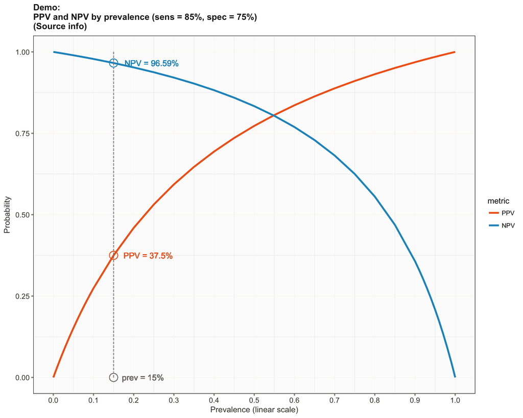

```r
## Plots:
# plot(PPV)
# m1 <- glm(PPV ~ prev)
# summary(m1)

# (2) Store as data frame:
df <- data.frame(prev.range, PPV, NPV)
# head(df)

# Reshape into long format:
library("tidyr")
library("dplyr")
df.long <- df %>%
              gather(metric, value, c(PPV, NPV))
# head(df.long)

# factor(df.long$metric)
df.long$metric <- factor(df.long$metric, # ensure factor and level order:
                         levels = c("PPV", "NPV") #,
                         # labels = c("PPV = p(true | positive decision)",
                         #            "NPV = p(false | negative decision)")
                         )
# factor(df.long$metric)

  ## Additional plot options:
  cur.PPV <- get.PPV(prev, sens, spec)
  cur.NPV <- get.NPV(prev, sens, spec)
  cur.PPV.label <- paste0("PPV = ", as_pc(cur.PPV), "%") # paste0("(", as_pc(prev), "%; ", as_pc(cur.PPV), "%)")
  cur.NPV.label <- paste0("NPV = ", as_pc(cur.NPV), "%") # paste0("(", as_pc(prev), "%; ", as_pc(cur.NPV), "%)")
  prev.label <- paste0("prev = ", as_pc(prev), "%")
  col.prev <- col.grey.2
  sens.spec.label <- paste0("(sens = ", as_pc(sens), "%, spec = ", as_pc(spec), "%)") # label
  x.just <- -.20
  y.just <- +.50

# (3) Visualize as a line plot (with ggplot2):
library(ggplot2)
# ggplot(data = df, aes(x = 1:length(prev), y = PPV)) + geom_line()

## A: Plot on linear scale:
p.lin <- ggplot(data = df.long, aes(x = prev.range, y = value, group = metric)) +
      geom_line(aes(color = metric), size = 1.2) +
      # geom_point(aes(color = metric, shape = metric), size = 2) +
      ## Mark and label prev:
      geom_line(aes(x = prev), color = col.prev, linetype = 3, size = .6) + # vertical line at prev
      geom_point(aes(x = prev, y = 0), color = col.prev, shape = 21, size = 5) + # mark (prev, 0)
      geom_text(aes(x = prev, y = 0, label = prev.label),
                color = col.prev, hjust = x.just, vjust = y.just, size = 4) + # label prev
      ## Mark and label current PPV/NPV:
      geom_point(aes(x = prev, y = cur.PPV),
                 color = col.ppv, shape = 21, size = 5) + # mark (prev, PPV)
      geom_text(aes(x = prev, y = cur.PPV, label = cur.PPV.label),
                color = col.ppv, hjust = x.just, vjust = y.just, size = 4) + # label PPV
      geom_point(aes(x = prev, y = cur.NPV),
                 color = col.npv, shape = 21, size = 5) + # mark (prev, NPV)
      geom_text(aes(x = prev, y = cur.NPV, label = cur.NPV.label),
                color = col.npv, hjust = x.just, vjust = y.just, size = 4) + # label NPV
      ## Scales:
      ## (a) linear scale:
      scale_x_continuous(breaks = seq(0, 1, by = .10)) +
      labs(title = paste0(name, ":\nPPV and NPV by prevalence ", sens.spec.label, "\n(", source, ")"),
           x = "Prevalence (linear scale)", y = "Probability") +
      ## (b) log scale:
      # scale_x_log10(breaks = prev.scale) +
      # labs(title = paste0(name, ":\nPPV and NPV by prevalence ", sens.spec, "\n(", source, ")"),
      #                    x = "Prevalence (logarithmic scale)", y = "Probability") +
      ## Colors:
      scale_color_manual(values = c(col.ppv, col.npv)) +
      # scale_fill_manual(values = c(col.ppv, col.npv), name = "Metric:") +
      my.theme.legend
p.lin
```

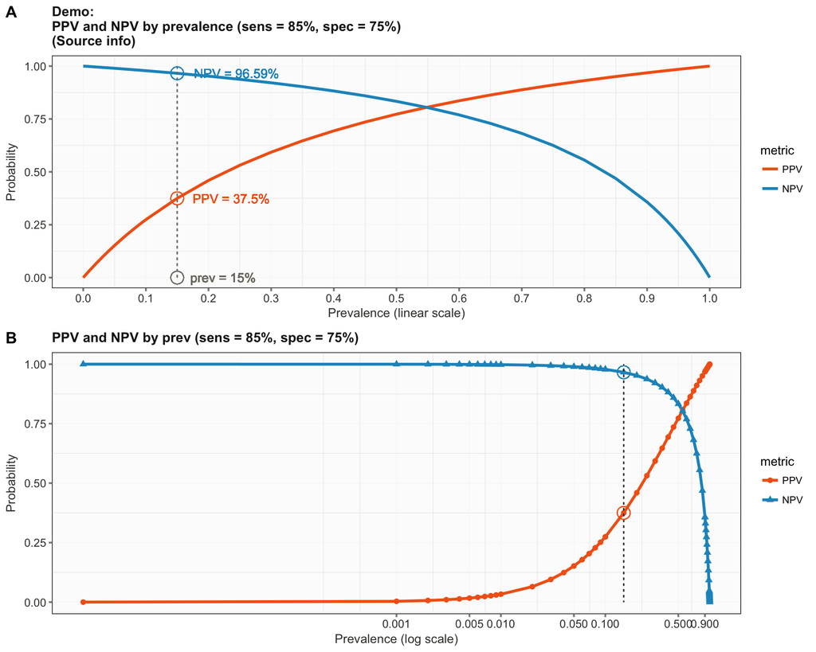

```r
## B: Plot on log scale:
p.log <- ggplot(data = df.long, aes(x = prev.range, y = value, group = metric)) +
  geom_line(aes(color = metric), size = 1.2) +
  geom_point(aes(color = metric, shape = metric), size = 2) +
  geom_line(aes(x = prev), color = "grey25", linetype = 3, size = .6) + # vertical line at prev
  geom_point(aes(x = prev, y = get.PPV(prev, sens, spec)),
             color = col.ppv, shape = 21, size = 5) + # mark PPV
  geom_point(aes(x = prev, y = get.NPV(prev, sens, spec)),
             color = col.npv, shape = 21, size = 5) + # mark NPV
  #geom_smooth(aes(color = metric), size = 1.2) +
  # scale_x_log10() +
  scale_x_log10(breaks = prev.scale) +
  # scale_x_continuous(breaks = seq(0, 1, by = .10)) +
  labs(title = paste0("PPV and NPV by prev ", sens.spec.label), x = "Prevalence (log scale)", y = "Probability") +
  scale_color_manual(values = c(col.ppv, col.npv, "firebrick")) +
  # scale_fill_manual(values = c(col.ppv, col.npv), name = "Metric:") +
  my.theme.legend
# p.log

# C: Combine both plots into one:
library(cowplot)
p.both <- plot_grid(p.lin, p.log,
                    labels = c("A", "B"),
                    nrow = 2, rel_heights = c(.50, .50))
p.both
```

#### Plot PV curves using base R:

Generic functions for PPV and NPV:

```r
## (1) Positive predictive value (PPV) from probabilities:
comp_PPV <- function(prev = num$prev, sens = num$sens, spec = num$spec) {

  PPV <- NA # initialize

  ## PPV = hits / positive decision = hits / (hits + false alarms):
  hi <- (prev * sens)
  fa <- (1 - prev) * (1 - spec)

  PPV <- hi / (hi + fa)

  return(PPV)
}

## (2) Negative predictive value (NPV) from probabilities:
comp_NPV <- function(prev = num$prev, sens = num$sens, spec = num$spec) {

  NPV <- NA # initialize

  ## NPV = cr / negative decision = cr / (cr + mi):
  cr <- (1 - prev) * spec
  mi <- prev * (1 - sens)

  NPV <- cr / (cr + mi)

  return(NPV)
}

## Check:
# comp_PPV(.1, .8, .9)
```

Plot both curves:

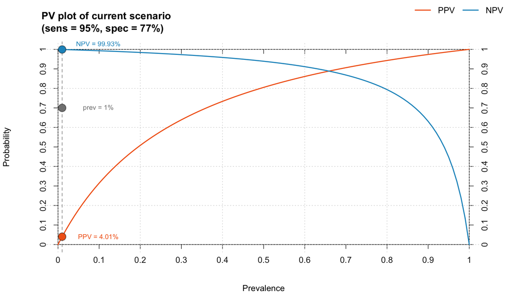

```r
# Basic numeric parameters:
prev <- .01
sens <- .95
spec <- .77

## Utility function from
## https://stackoverflow.com/questions/3932038/plot-a-legend-outside-of-the-plotting-area-in-base-graphics
add_legend <- function(...) {
  opar <- par(fig = c(0, 1, 0, 1), oma = c(0, 0, 0, 0), mar = c(0, 0, 0, 0), new = TRUE)
  on.exit(par(opar))
  plot(0, 0, type = 'n', bty = 'n', xaxt = 'n', yaxt = 'n')
  legend(...)
}

plot_PV <- function(prev, sens, spec,
                    show.PVprev = TRUE, show.PVpoints = TRUE, log.scale = FALSE) {

  ## Compute current PVs:
  PPV <- comp_PPV(prev, sens, spec)
  NPV <- comp_NPV(prev, sens, spec)

  ## Text labels:
  prev.lbl <- paste0("prev = ", as_pc(prev), "%")
  PPV.lbl <- paste0("PPV = ", as_pc(PPV), "%")
  NPV.lbl <- paste0("NPV = ", as_pc(NPV), "%")
  sens.spec.lbl <- paste0("(sens = ", as_pc(sens), "%, spec = ", as_pc(spec), "%)")
  title.lbl <- paste0("PV plot of current scenario", "\n", sens.spec.lbl)

  ## Parameters:
  col.prev <- grey(.50, alpha = .99) # prevalence # WAS: col.green.2
  col.axes <- grey(.10, alpha = .99) # axes
  col.bord <- grey(.10, alpha = .50) # borders (e.g., of points)
  cex.lbl <- .8 # size of text labels
  h.shift <- .088
  v.shift <- .030
  low.PV  <- .200 # threshold value for judging PPV or NPV to be low
  v.raise <- .700 # vertical raise of y-prev when PPV or NPV < low.PV

  ## Plot area:
  plot(0, xlim = c(0, 1), ylim = c(0, 1), axes = FALSE, ylab = "Probability", xlab = "Prevalence", type = "n")

  ## Title:
  title(title.lbl, adj = 0.0, line = 1.0)

  ## Axes:
  axis(side = 1, at = seq(0, 1, by = .1), labels = seq(0, 1, by = .1),
       pos = 0, tck = -.02, col.axis = col.axes, col.ticks = col.axes) # x at bottom
  axis(side = 1, at = seq(0, 1, by = .1), labels = FALSE,
       pos = 1, tck = -.02, col.axis = col.axes, col.ticks = col.axes) # x at top
  axis(side = 2, at = seq(0, 1, by = .1), labels = seq(0, 1, by = .1),
       pos = 0, tck = -.02, col.axis = col.axes, col.ticks = col.axes) # y at left
  axis(side = 4, at = seq(0, 1, by = .1), labels = seq(0, 1, by = .1),
       pos = 1, tck = -.02, col.axis = col.axes, col.ticks = col.axes) # y at right

  ## Grid:
  grid(col = grey(.8, .8))

  ## Curves:
  ## PPV:
  curve(expr = comp_PPV(x, sens, spec), from = 0, to = 1, add = TRUE, lty = 1, lwd = 2, col = col.ppv)
  ## NPV:
  curve(expr = comp_NPV(x, sens, spec), from = 0, to = 1, add = TRUE,  lty = 1, lwd = 2, col = col.npv)

  ## Lines:
  if (show.PVprev){
    abline(v = prev, lty = 2, lwd = 1, col = col.prev) # prev as vline
  }
  # abline(h = PPV, lty = 3, lwd = 1, col = col.ppv) # PPV as hline
  # abline(h = NPV, lty = 3, lwd = 1, col = col.npv) # NPV as hline
  # segments(x0 = 0, y0 = PPV, x1 = prev, y1 = PPV, lty = 2, lwd = 1.5, col = col.ppv) # PPV to y-axes
  # segments(x0 = 0, y0 = NPV, x1 = prev, y1 = NPV, lty = 2, lwd = 1.5, col = col.npv) # NPV to y-axes

  ## Points:
  ## prev:
  if (show.PVprev){
    if ((NPV < low.PV) | (PPV < low.PV)) { # y at v.raise:
      points(x = prev, y = 0 + v.raise, pch = 21, cex = 2, lwd = 1.5, col = col.bord, bg = col.prev)
    } else { # y at bottom (y = 0):
      points(x = prev, y = 0, pch = 21, cex = 2, lwd = 1.5, col = col.bord, bg = col.prev)
    }
  }

  if (show.PVpoints) {
    ## PPV:
    points(x = prev, y = PPV, pch = 21, cex = 2, lwd = 1.5, col = col.bord, bg = col.ppv)
    ## NPV:
    points(x = prev, y = NPV, pch = 21, cex = 2, lwd = 1.5, col = col.bord, bg = col.npv)
  }

  ## Labels:
  ## prev label:
  if (show.PVprev){
    if ((NPV < low.PV) | (PPV < low.PV)) { # y at v.raise:
      if ((prev < .50) | !(prev > 1 - h.shift)) {
        text(x = prev + h.shift, y = 0 + v.raise, labels = prev.lbl, col = col.prev, cex = cex.lbl) # on right
      } else {
        text(x = prev - h.shift, y = 0 + v.raise, labels = prev.lbl, col = col.prev, cex = cex.lbl) # on left+
      }
    } else { # y at bottom (y = 0):
      if ((prev < .50) | !(prev > 1 - h.shift)) {
        text(x = prev + h.shift, y = 0 + v.shift, labels = prev.lbl, col = col.prev, cex = cex.lbl) # on right
      } else {
        text(x = prev - h.shift, y = 0 + v.shift, labels = prev.lbl, col = col.prev, cex = cex.lbl) # on left+
      }
    }
  }

  if (show.PVpoints) {
    ## PPV label:
    if ((PPV < .75 & !(prev > 1 - h.shift)) | (prev < h.shift)) {
      text(x = prev + h.shift, y = PPV + .000, labels = PPV.lbl, col = col.ppv, cex = cex.lbl) # on right
    } else {
      text(x = prev - h.shift, y = PPV + v.shift, labels = PPV.lbl, col = col.ppv, cex = cex.lbl) # on left+
    }
    ## NPV label:
    if (NPV > .75 | (prev < h.shift)) {
      text(x = prev + h.shift, y = NPV + v.shift, labels = NPV.lbl, col = col.npv, cex = cex.lbl) # on right+
    } else {
      text(x = prev - h.shift, y = NPV - v.shift, labels = NPV.lbl, col = col.npv, cex = cex.lbl) # on left-
    }
  }

  ## Legend:
  # legend("bottom", legend = c("PPV", "NPV"),
  #       col = c(col.ppv, col.npv), lty = 1, lwd = 2, cex = 1, bty = "o", bg = "white")
  add_legend("topright", legend = c("PPV", "NPV"), lwd = 2, col = c(col.ppv, col.npv),
             horiz = TRUE, bty = 'n')

}

## Check:
plot_PV(.01, sens, spec, show.PVprev = TRUE, show.PVpoints = TRUE)
```

```r
# plot_PV(.50, sens, spec, show.PVprev = TRUE, show.PVpoints = TRUE)
# plot_PV(.99, sens, spec, show.PVprev = TRUE, show.PVpoints = TRUE)
```

+++ here now +++

### 3D graph

The following graphs illustrate how – for a given *prevalence* (`prev`) in some population – the metrics `PPV` and `NPV` vary as a function of the *sensitivity* (`sens`) and the *specificity* (`spec`) of the test:

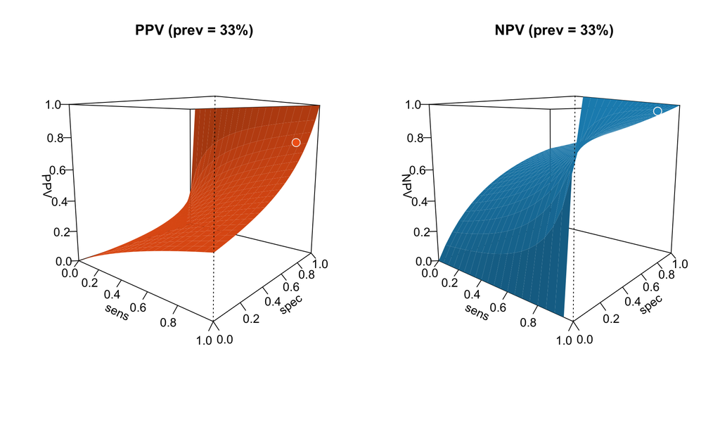

```r
## (1) Define parameters:
{
  ## Inputs:

  ## Compute PPV and NPV:
  cur.PPV <- get.PPV(prev, sens, spec)
  cur.NPV <- get.NPV(prev, sens, spec)

  # prev <- .15 # prevalence (to be set in parameter)
  sens.range <- seq(0.0, 1.0, by = .05) # range of sensitivity values
  spec.range <- seq(0.0, 1.0, by = .05) # range of specificity values
  z.lim <- c(0, 1) # range of z-axis

  # Basic graph parameters:
  my.theta <- 40  # horizontal viewing angle (higher values: more rotation)
  my.phi <- 10    # vertical viewing angle (higher values: higher viewpoint)
  my.expand <- .9 # values < 1 shrink expansion in z-direction
  my.d <- 1.2     # values > 1 lessen perspective effect
}

## (2) Compute PPV and NPV for an entire matrix of values:
pv.matrix <- function(prev, sens, spec, metric) {

  # initializing DF (as matrix to store and return results):
  n.rows <- length(sens)
  n.cols <- length(spec)
  matrix <- as.data.frame(matrix(NA,
                                 nrow = n.rows,
                                 ncol = n.cols))
  names(matrix) <- sens

  # loop through all rows and columns of pc.matrix:
  for (row in 1:n.rows) {
    for (col in 1:n.cols) {

      # Compute the needed model DV for the current cell value:
      cell.val <- NA

      if (metric == "PPV") {cell.val <- get.PPV(prev, sens[row], spec[col])} # compute PPV
      if (metric == "NPV") {cell.val <- get.NPV(prev, sens[row], spec[col])} # compute NPV

      # Store results:
      matrix[row, col] <- cell.val

    }
  }

  return(matrix)

}

## Use function to compute current values:
PPV.mat <- pv.matrix(prev, sens.range, spec.range, metric = "PPV")
NPV.mat <- pv.matrix(prev, sens.range, spec.range, metric = "NPV")

## Visualize as 3D graph (via persp):
x <- sens.range
y <- spec.range
z.ppv <- as.matrix(PPV.mat)
z.npv <- as.matrix(NPV.mat)

# persp(x, y, z.ppv)
# persp(x, y, z.ppv)

## Plot 2 plots (adjacent to each other):
{
par(mfrow = c(1, 2)) # Combine 2 plots in 1 row x 2 columns.
par(bg = "white")

## 3D plot for PPV:
p.ppv <- persp(x, y, z.ppv,
               theta = my.theta, phi = my.phi,  d = my.d, expand = my.expand,
               col = col.ppv, border = NA,
               ltheta = 200, shade = 0.10,
               ticktype = "detailed",
               xlab = "sens", ylab = "spec", zlab = "PPV", zlim = z.lim,
               main = paste0("PPV (prev = ", as_pc(prev), "%)"))

# Add cur.PPV to plot:
pmat <- p.ppv
mypoints <- trans3d(sens, spec, cur.PPV, pmat)
points(mypoints, pch = 21, col = "grey95", bg = col.ppv, cex = 1.5)

## 3D plot for NPV:
p.npv <- persp(x, y, z.npv,
               theta = my.theta, phi = my.phi,  d = my.d, expand = my.expand,
               col = col.npv, border = NA,
               ltheta = 200, shade = 0.10,
               ticktype = "detailed",
               xlab = "sens", ylab = "spec", zlab = "NPV", zlim = z.lim,
               main = paste0("NPV (prev = ", as_pc(prev), "%)"))

# Add cur.NPV to plot:
pmat <- p.npv
add.NPV <- trans3d(sens, spec, cur.NPV, pmat)
points(add.NPV, pch = 21, col = "grey95", bg = col.npv, lwd = 1.2, cex = 1.5)

par(mfrow = c(1, 1)) # Remove special settings.
}
```

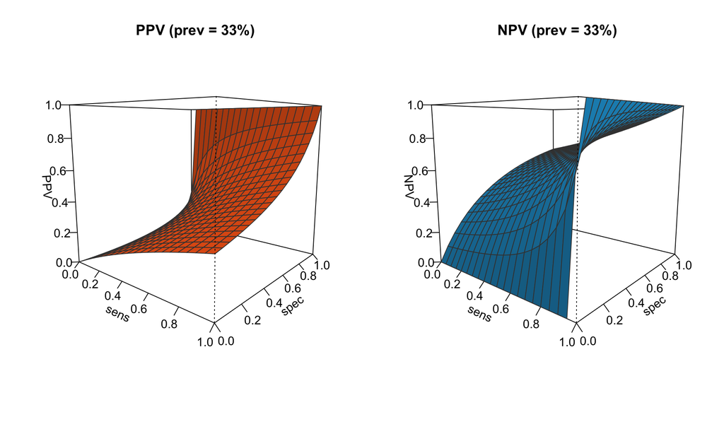

```r
## (3) As a function:
## (a) PPV only:
plot.PV.plane <- function(prev, metric = "PPV") {

  PV.mat <- pv.matrix(prev, sens.range, spec.range, metric)

  x <- sens.range
  y <- spec.range
  z.pv <- as.matrix(PV.mat)

  p.pv <- persp(x, y, z.pv,
               theta = my.theta, phi = my.phi, d = my.d, expand = my.expand,
               col = col.ppv, border = col.grey.3,
               ltheta = 200, shade = 0.10,
               ticktype = "detailed", xlab = "sens", ylab = "spec",
               zlab = "PPV",
               zlim = z.lim,
               main = paste0("PPV (prev = ", as_pc(prev), "%)"))

}

## Check:
plot.PV.plane(prev, metric = "PPV")

## (b) Both in 1 plot:
plot.PV.planes <- function(prev) {

  PPV.mat <- pv.matrix(prev, sens.range, spec.range, metric = "PPV")
  NPV.mat <- pv.matrix(prev, sens.range, spec.range, metric = "NPV")

  x <- sens.range
  y <- spec.range
  z.ppv <- as.matrix(PPV.mat)
  z.npv <- as.matrix(NPV.mat)

  # Plot 2 plots (adjacent to each other):
  {
    par(mfrow = c(1, 2)) # Combine 2 plots in 1 row x 2 columns.
    par(bg = "white")

    p.ppv <- persp(x, y, z.ppv,
                   theta = my.theta, phi = my.phi,  d = my.d, expand = my.expand,
                   col = col.ppv, border = col.grey.3,
                   ltheta = 200, shade = 0.10,
                   ticktype = "detailed", xlab = "sens", ylab = "spec", zlab = "PPV", zlim = z.lim,
                   main = paste0("PPV (prev = ", as_pc(prev), "%)"))

    p.npv <- persp(x, y, z.npv,
                   theta = my.theta, phi = my.phi,  d = my.d, expand = my.expand,
                   col = col.npv, border = col.grey.3,
                   ltheta = 200, shade = 0.10,
                   ticktype = "detailed", xlab = "sens", ylab = "spec", zlab = "NPV", zlim = z.lim,
                   main = paste0("NPV (prev = ", as_pc(prev), "%)"))

    par(mfrow = c(1, 1)) # Remove special settings.
  }

}

# Check:
plot.PV.planes(prev)
```

# Related Topics

Some topics for future extensions:

## Cell A bias and biased sampling of evidence

### Contingency table

Assume the following:

- 2 independent probabilities for features $A$ and $B$ that suggest a causal link (e.g., [$A$ = nuclear power station and $B$ = cancer] or [$A$ = aluminum deodorant and $B$ = cancer] etc.
- $A$ and $B$ are statistically independent (not causally related)

```r
A.cat <- c("alu", "no_alu") # A is binary
B.cat <- c("cancer", "healthy") # B is binary
pA <- .66
pB <- .10

# Simulation:
N <- 1000
A <- sample(x = A.cat, size = N, replace = TRUE, prob = c(pA, 1 - pA))
B <- sample(x = B.cat, size = N, replace = TRUE, prob = c(pB, 1 - pB))

# Contingency table:
BxA <- table(B, A)
BxA
```

```
#>          A
#> B         alu no_alu
#>   cancer   65     29
#>   healthy 614    292
```

```r
# sums and percentages:
colSums(BxA)
```

```
#>    alu no_alu
#>    679    321
```

```r
rowSums(BxA)
```

```
#>  cancer healthy
#>      94     906
```

```r
as_pc(BxA/sum(BxA))
```

```
#>          A
#> B          alu no_alu
#>   cancer   6.5    2.9
#>   healthy 61.4   29.2
```

```r
# 1st row percentages per column (pB):
as_pc(BxA[1,1]/sum(BxA[ , 1]))
```

```
#> [1] 9.57
```

```r
as_pc(BxA[1,2]/sum(BxA[ , 2]))
```

```
#> [1] 9.03
```

```r
# 1st col percentages per row (pA)
as_pc(BxA[1,1]/sum(BxA[1, ]))
```

```
#> [1] 69.15
```

```r
as_pc(BxA[2,1]/sum(BxA[2, ]))
```

```
#> [1] 67.77
```

```r
# Focus on row 1 suggests causal relationship A->B (which is simply due to pA).


# # Classify cases:
# X <- rep(NA, N)
# for (i in 1:length(A.cat)) {
#  for (j in 1:length(B.cat)) {
#
#    X[A == A.cat[i] & B == B.cat[j]] <- (i-1)*length(B.cat) + j
# }
# }
# table(X)
```

**ToDo:** Add measures of relatedness and causality (e.g., odds ratios, Matthew’s correlation, etc.)

### Biased sampling

Now assume that we do not have access to the overall contingency table, but only instances of individual cases in memory, from which we *sample* (or to which we *selectively attend*).

- Unbiased sampling would approximate the true contingency table.
- However, focusing on particular dimensions (of $A$ or $B$) would yield biased tables and estimates.

# Conclusion

## Important Insights

Materials for conclusions and possible quizzes:

- The sensitivity and specificity of a diagnostic test are insufficient to determine its PPV and NPV.
- Both PPV and NPV crucially depend on the specific *prevalence* of a particular person. Thus, always use an appropriate reference group to specify the risk of a particular person as accurately as possible.
- PPV and NPV show *opposite* trends (as a function of prevalence): When one is high, the other one tends to be low (and vice versa).
  - with increasing prevalence: PPV increases.
  - with increasing prevalence: NPV decreases.

## Recommendations for the General Population

- A risk-literate person should be aware that any diagnostic test (or clinical judgment) has 4 possible outcomes: 2 possible correct and 2 possible incorrect judgments.
- Whenever receiving a (positive or negative) test result, a good question is: What is the *probability* that this result is *wrong*?
  - Whenver receiving a positive (undesirable) test result: What is the PPV vs. p(false alarm) for me (or a random person from my reference group)?
  - Whenever receiving a negative (desirable) test result: What is the NPV vs. p(miss) for me (or a random person from my reference group)?

## Recommendations for Risk Professionals (e.g., Medical Health Experts)

More challenging conclusions and demands:

- All risk professionals should know how to determine and evaluate evidence for and against treatments (as a function of all 4 cells, rather than committing cell A bias).
- All risk professionals should be able to define and distinguish between *sensitivity* and *PPV* (as opposite conditional probabilities), as well as *specificity* and *NPV* (sic).
- All risk professionals should be able to use *contingency tables*, *natural frequency trees*, and *icon arrays* to solve Bayesian problems (of conditional probability).

[`RiskLiteracyTools_now.Rmd` updated on 2018-02-04 22:25:27 by [hn](http://neth.de/).]